# Assigning Risk Region to Tabular Data

Skyler Elmstrom

11/14/2020

I explored a few options for making spatial joins between our data and our new risk region boundaries. The first option is detailed here for reuse. It is open-source, doesn’t require ArcGIS, and easy to reproduce and use. The other options I wanted to at least mention in case we need alternatives are using the new [ArcGIS R-bridge](https://github.com/R-ArcGIS/r-bridge) and `arcgisbinding` package, using an ArcGIS python script, or completing the spatial join manually using ArcGIS. If there is interest, I can make instructions for any of the alternatives as well. This is meant to be a simple example and not meant for every use case. Feel free to reach out to me for assistance adapting it to your use case or if you have any issues or suggestions.

I highly recommend creating [R projects](http://www.rstudio.com/ide/docs/using/projects) rather than loose scripts and markdown not associated with a project to keep files organized. This example will be built within an R project.

If you’d like a more information on doing spatial analysis and visualization in R, check out:

- [Geocomputation with R](https://geocompr.robinlovelace.net/)
- [Geospatial Data Carpentry topics](https://datacarpentry.org/r-raster-vector-geospatial/)
- [Geospatial Data Visualization topics by Claus Wilke, 2019](https://clauswilke.com/dataviz/geospatial-data.html)

### Required Libraries

```r
library(tidyverse) # simple manipulation of data.frames, function chaining; works on sf spatial objects
library(sf) # vector data manipulation
library(here) # locates files relative to R project root directory
library(readxl) # for loading xlsx data sheets; R can only load CSV by default
```

### Loading Data

Start by loading your risk region shapefile into an `sf` object. Change the file path and name here as needed. If you need to use data outside of your project, you’ll need to use the full path to that data or temporarily change your working directory.

```r
USFE.riskregions <- here("data/RiskRegions_DWSC_Update_9292020.shp") %>% # path relative to main directory
  st_read()
```

Check your coordinate reference system (CRS) using `st_crs()` and make sure it matches the data you plan to join. If they are not the same, you’ll need to transform your data. Let me know if you need help with this. You may also want to store the CRS of your shapefile to define the CRS of your tabular data or for transformations between CRS.

```r
st_crs(USFE.riskregions) # Check CRS, should be WGS84
```

```
## Coordinate Reference System:
##   User input: 4326
##   wkt:
## GEOGCS["GCS_WGS_1984",
##     DATUM["WGS_1984",
##         SPHEROID["WGS_84",6378137.0,298.257223563]],
##     PRIMEM["Greenwich",0.0],
##     UNIT["Degree",0.0174532925199433],
##     AUTHORITY["EPSG","4326"]]
```

```r
crs.WGS84 <- st_crs(USFE.riskregions) # Store WGS84 CRS for defining CRS of tabular data
```

Next you’ll want to load the tabular data you want to perform the spatial join on. I’ll use our largest data set in this example but I’d advise not doing this. You’ll need to specify the names of the columns holding your x and y data and the CRS object we created earlier `with st_crs()`. If the CRS of your tabular data is different than your risk region shapefile, DO NOT assign it the same CRS as the risk regions! You’ll need to transform first.

```r
# Tabular data to sf spatial object
CEDEN.all <- read_excel("data/CEDEN_Data_Within_Boundary.xlsx") # Large file, be patient

# Excel data to sf object: needs x, y, CRS
CEDEN.sf <- CEDEN.all %>%
  st_as_sf(coords=c("TargetLongitude", "TargetLatitude"), crs = crs.WGS84)
```

### Spatial Join

The spatial join process is very simple once your data is loaded.

```r
# Join Excel Data to Risk Regions
CEDEN.sf <- st_join(CEDEN.sf, USFE.riskregions["Subregion"]) # joins "Subregion" name to point data
```

### Plotting

After your join is complete, you can plot or use your tabular data as normal. For inspiration on improving your ggplot maps, try: [r-spatial.org](https://www.r-spatial.org/r/2018/10/25/ggplot2-sf-2.html). Here is a (very) simple ggplot map just to make sure your data is working as intended:

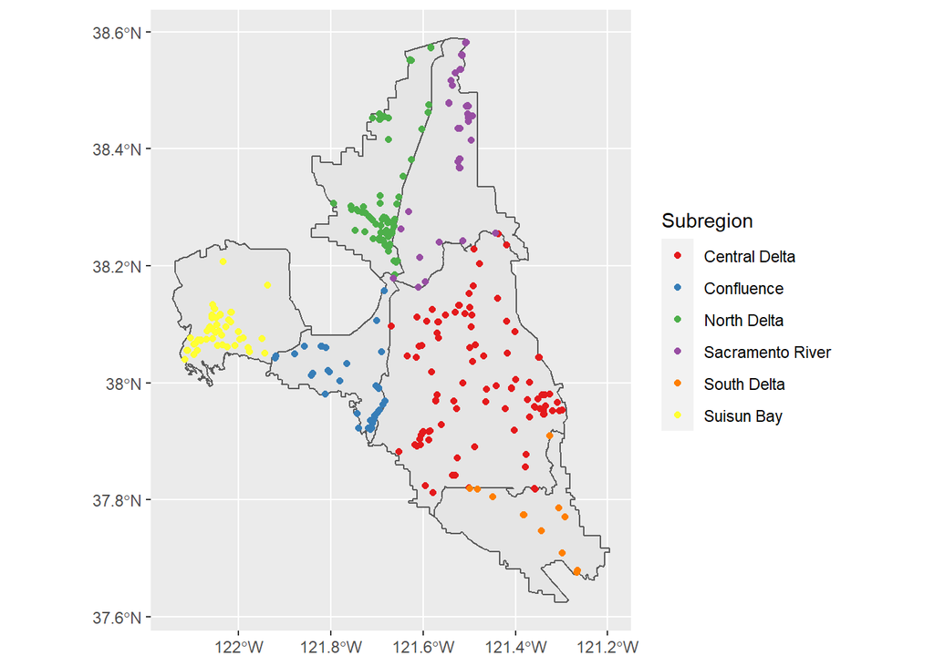

```r
library(RColorBrewer)

# Basic plot
ggplot() +
  geom_sf(data = USFE.riskregions) +
  geom_sf(data = CEDEN.sf, aes(color = Subregion)) +
  scale_color_brewer(palette = "Set1") # not color-blind safe
```

Here is a condensed code block for copying:

```r
# Libraries
library(tidyverse)
library(sf)
library(here)
library(readxl)

# Load Risk Region Shapefile
PROJECT.riskregions <- here("data/YOUR_REGION_SHAPEFILE_HERE.shp") %>%
  st_read()

st_crs(PROJECT.riskregions) # Check CRS, should match tabular data

# Load Tabular Data
crs.WGS84 <- st_crs(PROJECT.riskregions) # Store WGS84 CRS for defining CRS of tabular data
TABULAR_DATA <- read_excel("data/YOUR_EXCEL_DATA_HERE.xlsx")

# Excel Data to sf Object: needs x, y, CRS
TABULAR_DATA.sf <- TABULAR_DATA %>%
  st_as_sf(coords=c("LONGITUDE_COLUMN_NAME", "LATITUDE_COLUMN_NAME"), crs = crs.WGS84)

# Join Excel Data to Risk Regions
TABULAR_DATA.sf <- st_join(TABULAR_DATA.sf, PROJECT.riskregions["REGION_NAME_COLUMN"])
```

### (Optional) Write to File

Although the join speed is pretty quick, you’ll probably want to write your new table to a file instead of rejoining every time you need it. File size is an important consideration: if you export to csv, only use the `quote=False` parameter if your data fields do not have commas.

```r
write.csv(TABULAR_DATA, "data/NEWTABLE_NAME.csv", quote = F) # quote = F prevents file size expansion

# Alternatively, export to excel has smaller file size (excel is actually a compressed file while CSV is not)
library(writexl)

write_xlsx(TABULAR_DATA, "data/NEWTABLE_NAME.csv")
```